**Deep Learning for Mechanical Engineering**  
**Recurrent Neural Network (RNN)**

Instructor: Prof. Seungchul Lee  
http://iai.postech.ac.kr/  
Industrial AI Lab at POSTECH

# Problem 1: LSTM with TensorFlow

- In this problem, you will make a LSTM model to predict the half of a MNIST image using the other half.
- You will split a MNIST image into 28 pieces.
- MNIST is 28 x 28 image. The model predicts a piece of 1 x 28 image.
- First, 14 x 28 image will be feeded into a model as time series, then the model predict the last 14 x 28 image, recursively.

(0) Import libraries

```python
import tensorflow as tf
import numpy as np
import matplotlib.pyplot as plt
```

(1) Load MNIST Data

- Download MNIST data from the tensorflow tutorial example

```python
(train_imgs, train_labels), (test_imgs, test_labels) = tf.keras.datasets.mnist.load_data()

train_imgs = train_imgs / 255
test_imgs = test_imgs / 255

print('train_x: ', train_imgs.shape)
print('test_x: ', test_imgs.shape)
```

```
train_x:  (60000, 28, 28)
test_x:  (10000, 28, 28)
```

(2) Randomly plot a data with its label

```python
def batchmaker(x, y, n_batch):
    idx = np.random.randint(len(x), size = n_batch)
    return x[idx], y[idx]
```

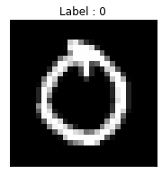

```python
train_x, train_y = batchmaker(train_imgs, train_labels, 10)
img = train_x[9,:].reshape(28, 28)

plt.figure(figsize = (5, 3))
plt.imshow(img,'gray')
plt.title("Label : {}".format(train_y[9]))
plt.xticks([])
plt.yticks([])
plt.show()
```

(3) Define LSTM Structure

```python
n_step = 14
n_input = 28

## LSTM shape
n_lstm1 = 10
n_lstm2 = 10

## Fully connected
n_hidden = 100
n_output = 28
```

```python
lstm_network = tf.keras.models.Sequential([
    tf.keras.layers.Input(shape = (n_step, n_input)),
    tf.keras.layers.LSTM(n_lstm1, return_sequences = True),
    tf.keras.layers.LSTM(n_lstm2),
    tf.keras.layers.Dense(n_hidden, activation = 'relu'),
    tf.keras.layers.Dense(n_output),
])

lstm_network.summary()
```

```
Model: "sequential_1"
_________________________________________________________________
 Layer (type)                Output Shape              Param #
=================================================================
 lstm_2 (LSTM)               (None, 14, 10)            1560

 lstm_3 (LSTM)               (None, 10)                840

 dense_2 (Dense)             (None, 100)               1100

 dense_3 (Dense)             (None, 28)                2828

=================================================================
Total params: 6,328
Trainable params: 6,328
Non-trainable params: 0
_________________________________________________________________
```

(4) Define Cost, Initializer and Optimizer Loss

- Regression: Squared loss

$$ \frac{1}{N} \sum_{i=1}^{N} (\hat{y}^{(i)} - y^{(i)})^2$$

Initializer

- Initialize all the empty variables

Optimizer

- AdamOptimizer: the most popular optimizer

```python
lstm_network.compile(optimizer = tf.keras.optimizers.Adam(learning_rate = 0.0005),
                     loss = 'mean_squared_error',
                     metrics = ['mae'])
```

(5) Define optimization configuration and then optimize

Highly recommand to use GPU or Colab.

```python
n_iter = 5000
n_prt = 100
batch_size = 50

for i in range(n_iter+1):
    train_x, train_y = batchmaker(train_imgs, train_labels, batch_size)

    for j in range(n_step):
        loss = lstm_network.train_on_batch(train_x[:, j:j+n_step, :], train_x[:, j+n_step, :])

    if i % n_prt == 0:
        train_loss = lstm_network.test_on_batch(train_x[:, 13:13+n_step, :], train_x[:, 13+n_step, :])
        print('Iteration: ', i, '     MSE_loss: ', train_loss[0])
```

```
Iteration:  0      MSE_loss:  0.0020172796212136745
Iteration:  100      MSE_loss:  0.0038742644246667624
Iteration:  200      MSE_loss:  0.002559578511863947
Iteration:  300      MSE_loss:  0.0025951650459319353
Iteration:  400      MSE_loss:  0.0008518496179021895
Iteration:  500      MSE_loss:  0.00035463989479467273
Iteration:  600      MSE_loss:  0.0009055454866029322
Iteration:  700      MSE_loss:  0.0015931202797219157
Iteration:  800      MSE_loss:  0.0014063797425478697
Iteration:  900      MSE_loss:  0.0026843687519431114
Iteration:  1000      MSE_loss:  0.0017316867597401142
Iteration:  1100      MSE_loss:  0.0007732169469818473
Iteration:  1200      MSE_loss:  0.0014056202489882708
Iteration:  1300      MSE_loss:  0.002031854819506407
Iteration:  1400      MSE_loss:  0.0033563761971890926
Iteration:  1500      MSE_loss:  0.0009611855493858457
Iteration:  1600      MSE_loss:  0.0007438090979121625
Iteration:  1700      MSE_loss:  0.0021451644133776426
Iteration:  1800      MSE_loss:  0.0008267456432804465
Iteration:  1900      MSE_loss:  0.0010156312491744757
Iteration:  2000      MSE_loss:  0.0029110582545399666
Iteration:  2100      MSE_loss:  0.0006799193215556443
Iteration:  2200      MSE_loss:  0.001156639656983316
Iteration:  2300      MSE_loss:  0.0023684122134000063
Iteration:  2400      MSE_loss:  0.003693124745041132
Iteration:  2500      MSE_loss:  0.00044868618715554476
Iteration:  2600      MSE_loss:  0.000783426221460104
Iteration:  2700      MSE_loss:  0.001869695377536118
Iteration:  2800      MSE_loss:  0.00032607829780317843
Iteration:  2900      MSE_loss:  0.003579868469387293
Iteration:  3000      MSE_loss:  0.0007400815957225859
Iteration:  3100      MSE_loss:  0.003115460043773055
Iteration:  3200      MSE_loss:  0.003396636573597789
Iteration:  3300      MSE_loss:  0.001842745579779148
Iteration:  3400      MSE_loss:  0.002975176088511944
Iteration:  3500      MSE_loss:  0.004135343246161938
Iteration:  3600      MSE_loss:  0.0029473036993294954
Iteration:  3700      MSE_loss:  0.0029053115285933018
Iteration:  3800      MSE_loss:  0.001023798598907888
Iteration:  3900      MSE_loss:  0.003148595103994012
Iteration:  4000      MSE_loss:  0.001909195794723928
Iteration:  4100      MSE_loss:  0.001016678404994309
Iteration:  4200      MSE_loss:  0.0006414643721655011
Iteration:  4300      MSE_loss:  0.0004061424406245351
Iteration:  4400      MSE_loss:  0.0023394939489662647
Iteration:  4500      MSE_loss:  0.0004554961633402854
Iteration:  4600      MSE_loss:  0.0006195014575496316
Iteration:  4700      MSE_loss:  0.000559675507247448
Iteration:  4800      MSE_loss:  0.00027325598057359457
Iteration:  4900      MSE_loss:  0.0009891536319628358
Iteration:  5000      MSE_loss:  0.0016172111500054598
```

(6) Test or Evaluate

- Predict the MNIST image
- MNIST is 28 x 28 image. The model predicts a piece of 1 x 28 image.
- First, 14 x 28 image will be feeded into a model, then the model predict the last 14 x 28 image, recursively.

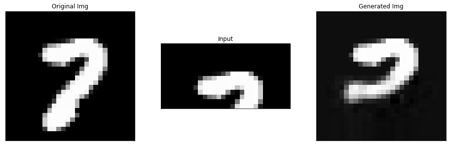

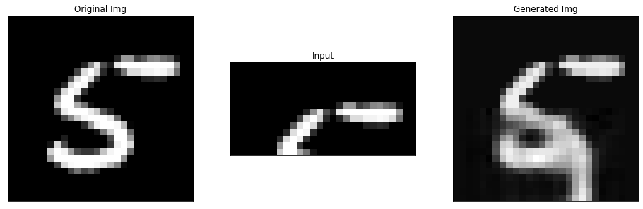

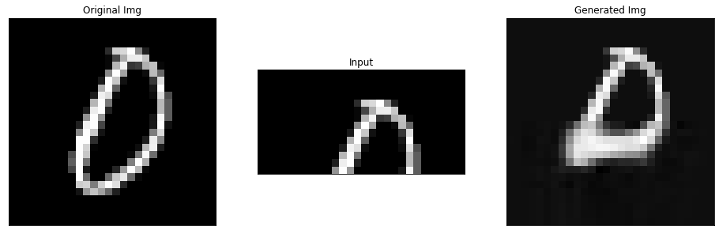

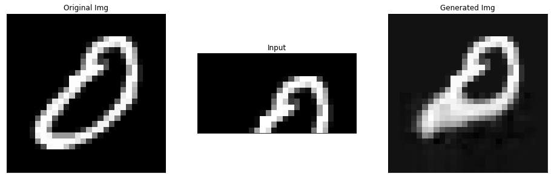

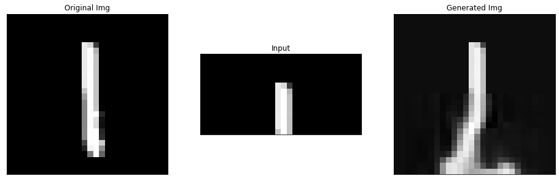

```python
test_x, test_y = batchmaker(test_imgs, test_labels, 5)

for idx in range(5):
    gen_img = []
    sample = test_x[idx, 0:14, :]
    input_img = sample.copy()
    feeding_img = test_x[idx, 0:0+n_step, :]

    for i in range(n_step):
        test_pred = lstm_network.predict(feeding_img.reshape(1, 14, 28))
        feeding_img = np.delete(feeding_img, 0, 0)
        feeding_img = np.vstack([feeding_img, test_pred])
        gen_img.append(test_pred)

    for i in range(n_step):
        sample = np.vstack([sample, gen_img[i]])

    plt.figure(figsize = (16, 5))
    plt.subplot(1, 3 ,1)
    plt.imshow(test_x[idx], 'gray')
    plt.title('Original Img')
    plt.xticks([])
    plt.yticks([])

    plt.subplot(1, 3, 2)
    plt.imshow(input_img, 'gray')
    plt.title('Input')
    plt.xticks([])
    plt.yticks([])

    plt.subplot(1, 3, 3)
    plt.imshow(sample, 'gray')
    plt.title('Generated Img')
    plt.xticks([])
    plt.yticks([])
    plt.show()
```

# Problem 2

- In this problem, we have bearing data with 3 classes (healthy, inner fault, outer fault).
- The objective is to classify the given data using state-of-the-art deep learning models.
- You will build and test a deep learning model.

### Dataset Description

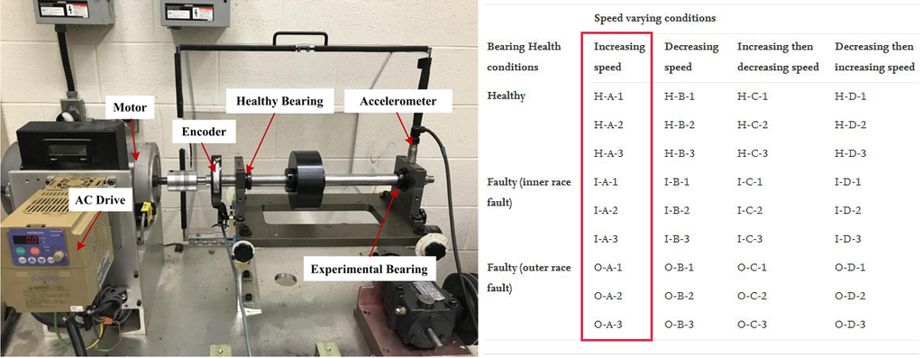

### Download & Load Data

We already made the data ready for you. You can download [the data](https://www.dropbox.com/s/icxa8mmqhang6qt/bearing_dataset.zip?dl=1) in .npy format. Six files are prepared for a train set and three files for a test set.

- Healty_train_1.npy
- Healty_train_2.npy
- InnerFault_train_1.npy
- InnerFault_train_2.npy
- OuterFault_train_1.npy
- OuterFault_train_2.npy
- Healty_test.npy
- InnerFault_test.npy
- OuterFault_test.npy

## 2.1 Plot all data with the title of its filename.

```python
import tensorflow as tf
import numpy as np
import os
import matplotlib.pyplot as plt
%matplotlib inline
```

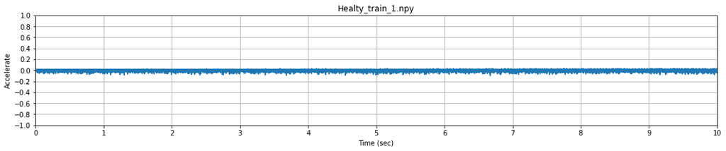

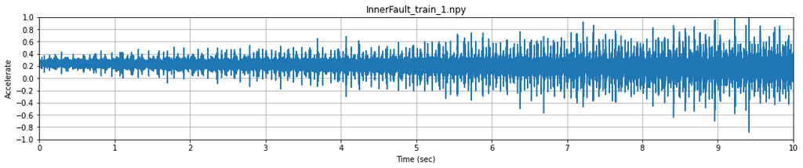

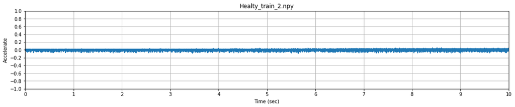

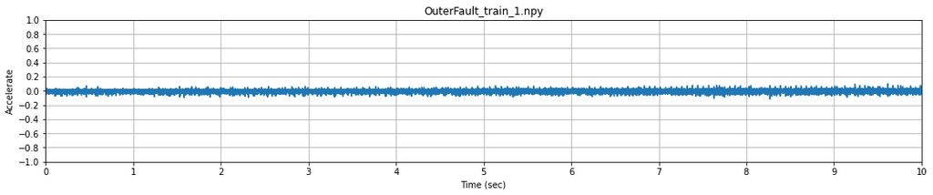

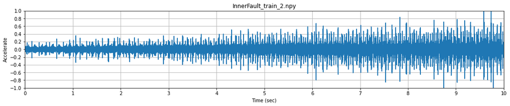

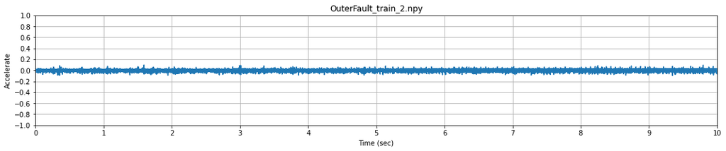

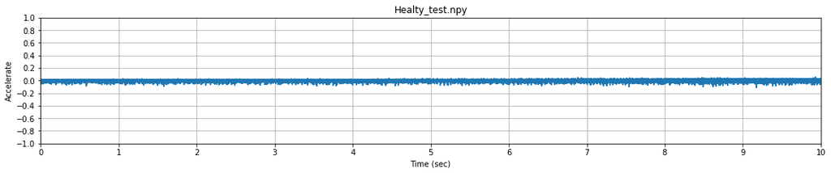

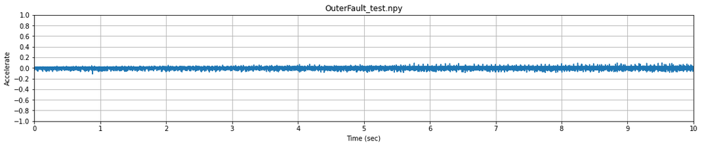

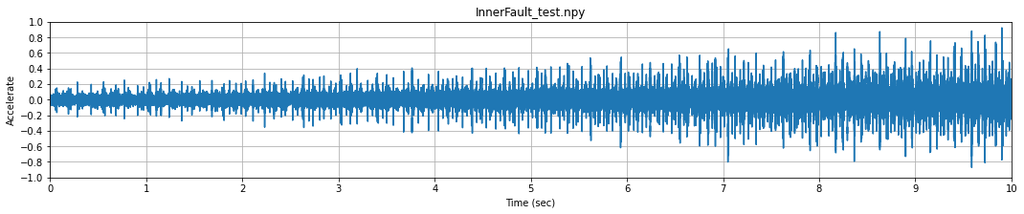

```python
def plotAllData(*pathes):
    for path in pathes:
        path = path+'/' if path[-1] != '/' else path
        for f in os.listdir(path):
            data = np.load(path+f)
            plt.figure(figsize = (18, 3)); plt.plot(data); plt.title(f); plt.grid('on')
            plt.yticks(np.arange(-1, 1.01, 0.2)); plt.ylim([-1, 1]); plt.ylabel('Accelerate')
            plt.xticks(range(0, 2000001, 200000), range(11));  plt.xlim([0, 2000001]); plt.xlabel('Time (sec)');
            plt.show()

plotAllData('./data_files/train', './data_files/test')
```

In the following subproblems, you will be introduced deep learning models which are used for time-series data classification. You are asked to build the model with the given architecture and evaluate the performance.

### Various deep learning models for time-series data classification

In the deep learning field, there are plenty of models for time-series data classification. Compared to conventional machine learning algorithms, recent deep neural network models show much higher accuracy as you can see in the table below. In this problem, we will build the **CNN-LSTM model** which is one of the most successful, and whose elements are covered in this course.

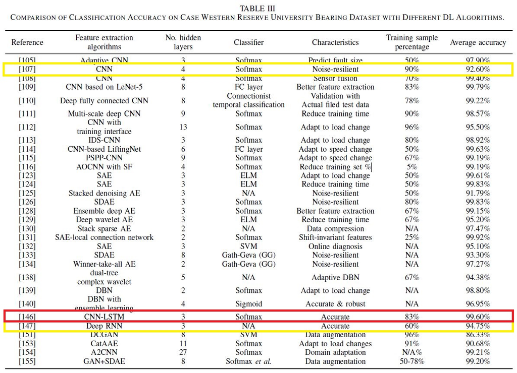

*"Deep Learning Algorithms for Bearing Fault Diagnostics – A Comprehensive Review", 2020, S Zhang et al.*

### Implementation of CNN-LSTM model

The CNN-LSTM model is introduced in ["An Improved Bearing Fault Diagnosis Method using One-Dimensional CNN and LSTM"](https://www.sv-jme.eu/?ns_articles_pdf=/ns_articles/files/ojs/5249/public/5249-29704-1-PB.pdf&id=6130). The authors combined 1D CNN and LSTM succesfully and it shows high performance in terms of both computation time and accuracy. The following configuration shows a part of the structure of the model. The model takes the segmented data as an input. A data segment which has a length of 1,600 is randomly cropped from the original time-series data.

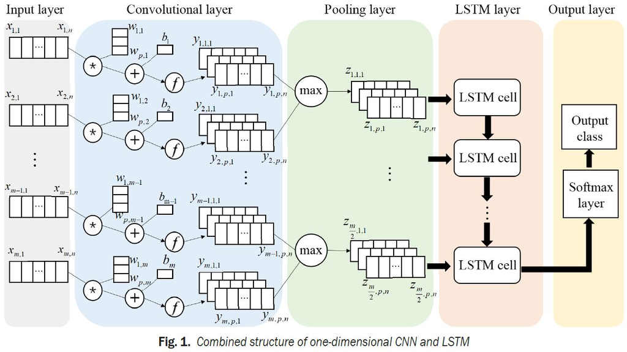

## 2.2 Build the model based on the above information and print the structure.

Build the model based on the above information and print the structure. You can freely assign the other parameters that are not described in the above configuration in order to achieve better performance. (You don't need to refer the original paper for those.) Please refer to the summary of the model structure.

You will use the 1D convolution layer for this problem. We have learned 2D convolution in class and 1D convolution is nothing but 2D convolution with a height as 1.

**Input_shape of data = (1600,)**

```python
model = tf.keras.models.Sequential([
    tf.keras.layers.Reshape((80, 20), input_shape = (1600,)),
    tf.keras.layers.Conv1D(filters = 32, kernel_size = 64, activation = 'relu', padding = 'SAME'),
    tf.keras.layers.MaxPool1D(pool_size = 2, strides = 2),
    tf.keras.layers.Dropout(rate = 0.2),
    tf.keras.layers.LSTM(128),
    tf.keras.layers.Dense(3, activation = 'softmax')
])

model.compile(loss = 'categorical_crossentropy',
              optimizer = tf.keras.optimizers.Adam(0.004),
              metrics = ['accuracy'])
model.summary()
```

```
Model: "sequential_2"
_________________________________________________________________
 Layer (type)                Output Shape              Param #
=================================================================
 reshape (Reshape)           (None, 80, 20)            0

 conv1d (Conv1D)             (None, 80, 32)            40992

 max_pooling1d (MaxPooling1D  (None, 40, 32)           0
 )

 dropout (Dropout)           (None, 40, 32)            0

 lstm_4 (LSTM)               (None, 128)               82432

 dense_4 (Dense)             (None, 3)                 387

=================================================================
Total params: 123,811
Trainable params: 123,811
Non-trainable params: 0
_________________________________________________________________
```

## 2.3 Create trainset and testset

Create trainset and testset to feed the model you designed. Set the number of segments equals to 4,000 for trainset and 1,000 for testset (for each class).

```python
def createDataset(folder, num, length, n_class, normalization = False):
    rtn_x, rtn_y = [], []
    nf = len(os.listdir(folder))//n_class
    for n, f in enumerate(os.listdir(folder)):
        dat = np.load(folder + f)
        idx = np.random.choice(range(len(dat) - length), size = num, replace = False)
        if normalization:
            norm = lambda x: (x - np.min(x)) / (np.max(x) - np.min(x)) * 255
        else:
            norm = lambda x: x
        data = np.stack([norm(dat[i:i + length]) for i in idx], axis = 0)
        rtn_x.append(data)
        rtn_y.append(n//nf * np.ones([num, 1]))
    return np.vstack(rtn_x), tf.keras.utils.to_categorical(np.vstack(rtn_y))

x_train, y_train = createDataset('./data_files/train/', num = 2000, length = 1600, n_class = 3)
x_test, y_test = createDataset('./data_files/test/', num = 1000, length = 1600, n_class = 3)
print(x_train.shape, y_train.shape, x_test.shape, y_test.shape)
```

```
(12000, 1600) (12000, 3) (3000, 1600) (3000, 3)
```

## 2.4 Plot a random segment for both trainset and testset.

Hint: Reshape the segment into (1600, ) if necessary.

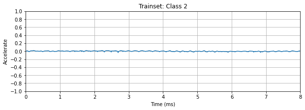

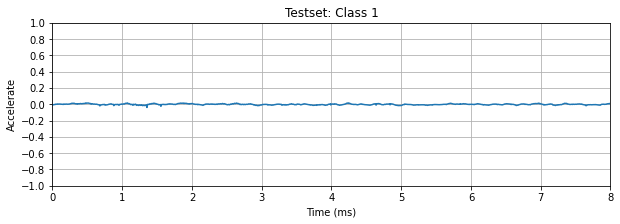

```python
r = np.random.randint(len(x_train))
plt.figure(figsize = (10, 3)); plt.plot(x_train[r]);
plt.title('Trainset: Class {}'.format(np.argmax(y_train[r]) + 1)); plt.grid('on')
plt.yticks(np.arange(-1, 1.01, 0.2)); plt.ylim([-1, 1]); plt.ylabel('Accelerate')
plt.xticks(range(0, 1601, 200), range(9));  plt.xlim([0, 1600]); plt.xlabel('Time (ms)');
plt.show() # Sampling frequency: 200,000Hz

r = np.random.randint(len(x_test))
plt.figure(figsize=(10, 3)); plt.plot(x_test[r]);
plt.title('Testset: Class {}'.format(np.argmax(y_test[r]) + 1)); plt.grid('on')
plt.yticks(np.arange(-1, 1.01, 0.2)); plt.ylim([-1, 1]); plt.ylabel('Accelerate')
plt.xticks(range(0, 1601, 200), range(9));  plt.xlim([0, 1600]); plt.xlabel('Time (ms)');
plt.show()
```

## 2.5 Train the model and print the training procedure.

```python
saver = tf.keras.callbacks.ModelCheckpoint('trained_model/cnn_lstm.ckpt', monitor = 'val_acc', verbose = 0,
                                           save_best_only = True, save_weights_only = True, mode = 'auto', period = 1)
stop = tf.keras.callbacks.EarlyStopping(monitor = 'val_loss', min_delta = 0, patience = 10, verbose = 0,
                                        mode = 'auto', baseline = None, restore_best_weights = False)
history = model.fit(x_train, y_train, validation_data = (x_test, y_test), epochs = 100, batch_size = 50, callbacks = [saver, stop])
```

[output not shown]

[output not shown]

[output not shown]

[output not shown]

[output not shown]

[output not shown]

[output not shown]

[output not shown]

[output not shown]

[output not shown]

[output not shown]

[output not shown]

[output not shown]

## 2.6 Evaluate the model in terms of accuracy of the testset.

```python
score = model.evaluate(x_test, y_test, batch_size = 50)
```

[output not shown]

# Problem 3

- In this problem, we are going to predict sequence data using LSTM model
- You will build and test a deep learning model.

### Download & Load Data

We've already prepared the data. You can download [the data](https://www.dropbox.com/s/uu93fkppyf6zoig/P3.csv?dl=1) in .csv format.

```python
import pandas as pd
from sklearn.preprocessing import MinMaxScaler
import tensorflow as tf
df = pd.read_csv('./data_files/P3.csv')
df['dt'] = pd.to_datetime(df['dt'])
df = df.set_index('dt')
df
```

| dt | Combustor power | Compressor power | Blade tip temperature | Compressor pressure | Blade tip acceleration | Relative pressure | Blade tip velocity |
| --- | --- | --- | --- | --- | --- | --- | --- |
| 2006-12-16 17:24:00 | 4.216 | 0.418 | 234.84 | 18.4 | 0.0 | 1.0 | 17.0 |
| 2006-12-16 17:25:00 | 5.360 | 0.436 | 233.63 | 23.0 | 0.0 | 1.0 | 16.0 |
| 2006-12-16 17:26:00 | 5.374 | 0.498 | 233.29 | 23.0 | 0.0 | 2.0 | 17.0 |
| 2006-12-16 17:27:00 | 5.388 | 0.502 | 233.74 | 23.0 | 0.0 | 1.0 | 17.0 |
| 2006-12-16 17:28:00 | 3.666 | 0.528 | 235.68 | 15.8 | 0.0 | 1.0 | 17.0 |
| ... | ... | ... | ... | ... | ... | ... | ... |
| 2010-11-26 20:58:00 | 0.946 | 0.000 | 240.43 | 4.0 | 0.0 | 0.0 | 0.0 |
| 2010-11-26 20:59:00 | 0.944 | 0.000 | 240.00 | 4.0 | 0.0 | 0.0 | 0.0 |
| 2010-11-26 21:00:00 | 0.938 | 0.000 | 239.82 | 3.8 | 0.0 | 0.0 | 0.0 |
| 2010-11-26 21:01:00 | 0.934 | 0.000 | 239.70 | 3.8 | 0.0 | 0.0 | 0.0 |
| 2010-11-26 21:02:00 | 0.932 | 0.000 | 239.55 | 3.8 | 0.0 | 0.0 | 0.0 |

2075259 rows × 7 columns

In order to reduce the computation time, data were resampled in hour units to reduce the computational time (original data is provided in minutes). This will reduce the size of data from 2075259 to 34589 but keep the overall strucure of data as shown in the below.

```python
df_resample = df.resample('h').mean()
df_resample
```

| dt | Combustor power | Compressor power | Blade tip temperature | Compressor pressure | Blade tip acceleration | Relative pressure | Blade tip velocity |
| --- | --- | --- | --- | --- | --- | --- | --- |
| 2006-12-16 17:00:00 | 4.222889 | 0.229000 | 234.643889 | 18.100000 | 0.0 | 0.527778 | 16.861111 |
| 2006-12-16 18:00:00 | 3.632200 | 0.080033 | 234.580167 | 15.600000 | 0.0 | 6.716667 | 16.866667 |
| 2006-12-16 19:00:00 | 3.400233 | 0.085233 | 233.232500 | 14.503333 | 0.0 | 1.433333 | 16.683333 |
| 2006-12-16 20:00:00 | 3.268567 | 0.075100 | 234.071500 | 13.916667 | 0.0 | 0.000000 | 16.783333 |
| 2006-12-16 21:00:00 | 3.056467 | 0.076667 | 237.158667 | 13.046667 | 0.0 | 0.416667 | 17.216667 |
| ... | ... | ... | ... | ... | ... | ... | ... |
| 2010-11-26 17:00:00 | 1.725900 | 0.061400 | 237.069667 | 7.216667 | 0.0 | 0.000000 | 12.866667 |
| 2010-11-26 18:00:00 | 1.573467 | 0.053700 | 237.531833 | 6.620000 | 0.0 | 0.000000 | 0.000000 |
| 2010-11-26 19:00:00 | 1.659333 | 0.060033 | 236.741000 | 7.056667 | 0.0 | 0.066667 | 0.000000 |
| 2010-11-26 20:00:00 | 1.163700 | 0.061167 | 239.396000 | 4.913333 | 0.0 | 1.066667 | 0.000000 |
| 2010-11-26 21:00:00 | 0.934667 | 0.000000 | 239.690000 | 3.800000 | 0.0 | 0.000000 | 0.000000 |

34589 rows × 7 columns

In order to train the deep learning model using dataset, we are going to change the data type from dataframe to array.

```python
dataset = df_resample.values
print(dataset.shape)
```

```
(34589, 7)
```

## 3.1 Data visualization

Plot all data with the title of its variable name.

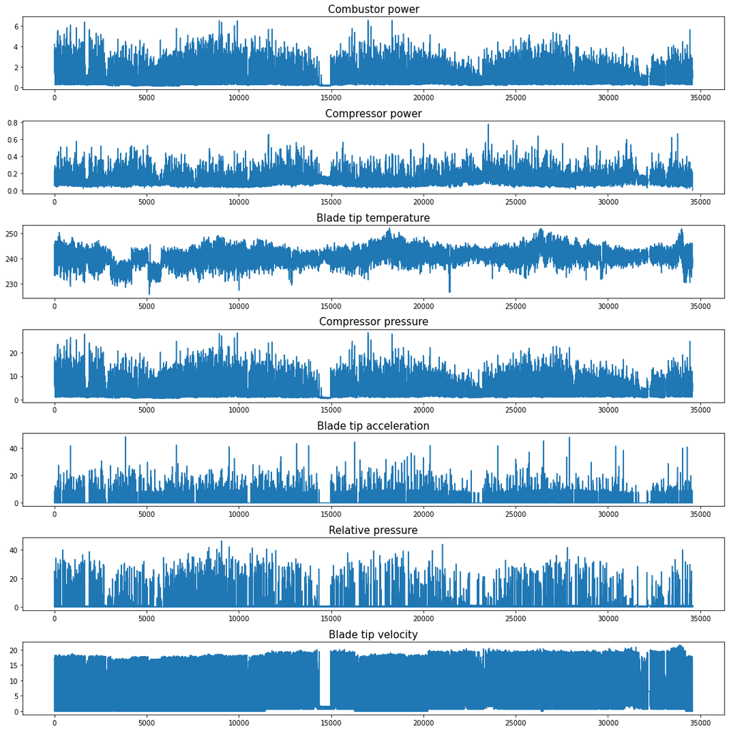

```python
plt.figure(figsize = (15, 15))
for i in range(7):
    plt.subplot(7, 1, i+1)
    plt.plot(dataset[:, i])
    plt.title(df.columns[i], fontsize = 15)
plt.tight_layout()
plt.show()
```

## 3.2 Preprocessing

Each variables has different scale. Normalize the dataset.

```python
scaler = MinMaxScaler(feature_range = (0, 1))
norm_dataset = scaler.fit_transform(dataset)
```

```python
print('min value:{:.1f}, max value:{:.1f}'.format(np.min(norm_dataset), np.max(norm_dataset)))
```

```
min value:0.0, max value:1.0
```

## 3.3 Split dataset

(3.3.1) Referring to below image, create train and target data.

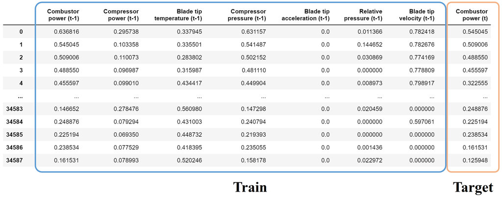

```python
train_data, target_data = norm_dataset[:-1, :], norm_dataset[1:, 0]
```

(3.3.2) Set the trainset to 3 years and the testset to the remaining datasets.  
Hint: Since the data set is recorded hour by hour, 365*24 data are one-year data

```python
n_train_time = 365 * 24 * 3

train_X, train_y = train_data[:n_train_time, :], target_data[:n_train_time]
test_X, test_y = train_data[n_train_time:, :], target_data[n_train_time:]

train_X = train_X.reshape((train_X.shape[0], 1, train_X.shape[1]))
test_X = test_X.reshape((test_X.shape[0], 1, test_X.shape[1]))

print(train_X.shape, train_y.shape, test_X.shape, test_y.shape)
```

```
(26280, 1, 7) (26280,) (8308, 1, 7) (8308,)
```

## 3.4 Create model

Create a model by referring to below result. Use mean squared error as loss function.

```python
model = tf.keras.models.Sequential()
model.add(tf.keras.layers.LSTM(100,
                               input_shape = (train_X.shape[1], train_X.shape[2]),
                               return_sequences = True))
model.add(tf.keras.layers.LSTM(100))
model.add(tf.keras.layers.Dense(1))
model.compile(loss = 'mean_squared_error', optimizer = 'adam')
model.summary()
```

```
Model: "sequential_3"
_________________________________________________________________
 Layer (type)                Output Shape              Param #
=================================================================
 lstm_5 (LSTM)               (None, 1, 100)            43200

 lstm_6 (LSTM)               (None, 100)               80400

 dense_5 (Dense)             (None, 1)                 101

=================================================================
Total params: 123,701
Trainable params: 123,701
Non-trainable params: 0
_________________________________________________________________
```

## 3.5 Train the model

```python
history = model.fit(train_X,
                    train_y,
                    epochs = 30,
                    batch_size = 128,
                    validation_data = (test_X, test_y),
                    verbose = 2,
                    shuffle = True)
```

```
206/206 - 4s - loss: 0.0125 - val_loss: 0.0075 - 4s/epoch - 22ms/step
206/206 - 1s - loss: 0.0095 - val_loss: 0.0075 - 1s/epoch - 6ms/step
206/206 - 1s - loss: 0.0094 - val_loss: 0.0074 - 1s/epoch - 6ms/step
206/206 - 1s - loss: 0.0094 - val_loss: 0.0074 - 1s/epoch - 6ms/step
206/206 - 1s - loss: 0.0093 - val_loss: 0.0074 - 1s/epoch - 6ms/step
206/206 - 1s - loss: 0.0093 - val_loss: 0.0074 - 1s/epoch - 5ms/step
206/206 - 1s - loss: 0.0093 - val_loss: 0.0074 - 1s/epoch - 6ms/step
206/206 - 1s - loss: 0.0093 - val_loss: 0.0073 - 1s/epoch - 5ms/step
206/206 - 1s - loss: 0.0093 - val_loss: 0.0074 - 1s/epoch - 6ms/step
206/206 - 1s - loss: 0.0093 - val_loss: 0.0073 - 1s/epoch - 5ms/step
206/206 - 1s - loss: 0.0093 - val_loss: 0.0073 - 1s/epoch - 5ms/step
206/206 - 1s - loss: 0.0093 - val_loss: 0.0074 - 1s/epoch - 6ms/step
206/206 - 1s - loss: 0.0092 - val_loss: 0.0074 - 998ms/epoch - 5ms/step
206/206 - 1s - loss: 0.0093 - val_loss: 0.0074 - 1s/epoch - 5ms/step
206/206 - 1s - loss: 0.0092 - val_loss: 0.0073 - 1s/epoch - 5ms/step
206/206 - 1s - loss: 0.0092 - val_loss: 0.0075 - 1s/epoch - 5ms/step
206/206 - 1s - loss: 0.0092 - val_loss: 0.0074 - 1s/epoch - 6ms/step
206/206 - 1s - loss: 0.0092 - val_loss: 0.0074 - 1s/epoch - 6ms/step
206/206 - 1s - loss: 0.0092 - val_loss: 0.0075 - 999ms/epoch - 5ms/step
206/206 - 1s - loss: 0.0092 - val_loss: 0.0073 - 1s/epoch - 5ms/step
206/206 - 1s - loss: 0.0092 - val_loss: 0.0074 - 1s/epoch - 6ms/step
206/206 - 1s - loss: 0.0092 - val_loss: 0.0073 - 1s/epoch - 6ms/step
206/206 - 1s - loss: 0.0092 - val_loss: 0.0074 - 1s/epoch - 6ms/step
206/206 - 1s - loss: 0.0092 - val_loss: 0.0074 - 1s/epoch - 6ms/step
206/206 - 1s - loss: 0.0092 - val_loss: 0.0073 - 1s/epoch - 5ms/step
206/206 - 1s - loss: 0.0091 - val_loss: 0.0073 - 1s/epoch - 5ms/step
206/206 - 1s - loss: 0.0091 - val_loss: 0.0073 - 1s/epoch - 6ms/step
206/206 - 1s - loss: 0.0091 - val_loss: 0.0073 - 1s/epoch - 6ms/step
206/206 - 1s - loss: 0.0091 - val_loss: 0.0075 - 1s/epoch - 6ms/step
206/206 - 1s - loss: 0.0091 - val_loss: 0.0074 - 1s/epoch - 5ms/step
```

## 3.6 Plot the result

Predict your test dataset and compare the prediction value with target value.

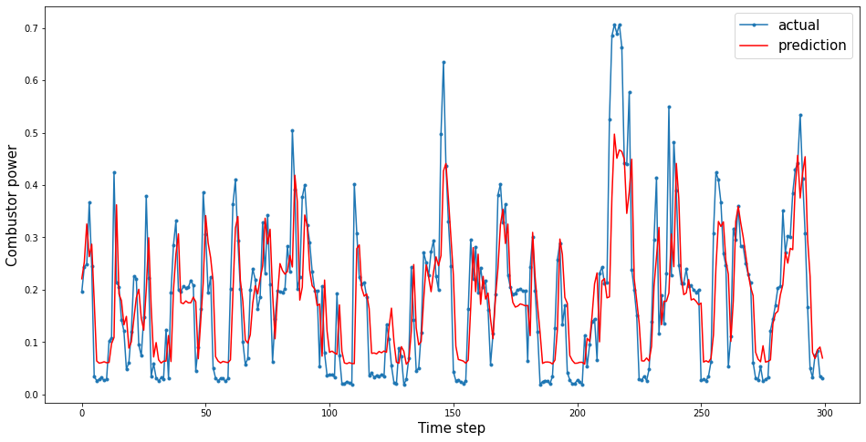

```python
yhat = model.predict(test_X)
plt.figure(figsize = (16,8))
aa = [x for x in range(300)]
plt.plot(aa, test_y[:300], marker = '.', label = "actual")
plt.plot(aa, yhat[:300], 'r', label = "prediction")
plt.ylabel('Combustor power', size = 15)
plt.xlabel('Time step', size = 15)
plt.legend(fontsize = 15)
plt.show()
```